# Impact Of Cold Shower Exposure On Cortisol Levels Controlling Stress

Katherine Quach

3/16/2025

# Term Project Description

My project builds upon the study referenced below. I have proposed a potential follow-up experiment to extend the study’s findings. The project utilizes simulated data, structured and analyzed as if collected from a real experiment. While the outcomes do not provide scientific evidence, they showcase my skills in formulating and addressing relevant biological questions through statistics, experimental design, and programming.

### Article citation:

Buijze GA, Sierevelt IN, van der Heijden BCJM, Dijkgraaf MG, Frings-Dresen MHW (2016) The Effect of Cold Showering on Health and Work: A Randomized Controlled Trial. PLoS ONE 11(9): e0161749. doi:10.1371/journal.pone.0161749

### Brief statement on the findings from the original article that led to your followup experiemnt:

In “The Effect of Cold Showering on Health and Work: A Randomized Control Trial”, the central goal of the experiment was to observe and determine whether incremental exposure to cold water would improve health outcomes such as quality of life, work productivity, and anxiety. The study concluded that cold water exposure after a warm shower increases individual well-being and promotes work attendance when the participants had mild illness symptoms, hence booting productivity. Furthermore, cold water exposure can be beneficial in other ways as well, such as affecting the level of cortisol in the body as a response to stress. This new connection stimulated a follow-up experiment that focuses on observing any additional effects of cold water exposure after taking a hot shower to the volume of cortisol produced in the participant’s body.

# The Question

Is there a significant difference in the volume of cortisol present in the blood between individuals who are exposed to cold water immediately after a hot shower and individuals who are not exposed to cold water at all after a hot shower?

#### Disclaimer: This project analyzes simulated data. The questions and hypotheses are real, but the results and conclusions are not.

### *Rationale and Background:*

Taking a shower, whether it be at the end or the beginning of the day, is commonly done to maintain good hygiene. To many individuals, it can serve as a relaxation technique to wind down at the end of the day or become an energy boost to start the day. Showering with cold water can improve blood circulation in the human body because lower internal body temperatures increase blood circulation, delivering more oxygenated blood to the tissues (Cherney 2020). Cold water has commonly been used to treat illnesses for centuries and can be seen in today’s latest cold therapy technology; whole-body cryotherapy. This can be defined as emerging the entire body in a chamber that consists of cold air with temperatures ranging from -110°C to -140°C. This method is commonly utilized in sports because of the beneficial effects towards recovery and performance in athletes. Various modes of cold water immersion have similar, beneficial effects that modulate immune responses (Buijze et al.). For instance, continuous stress causes an increase in inflammation, which can lead to anxiety. Therefore, hydrotherapy has been an approach introduced to reduce inflammation. As inflammation is linked to anxiety, it can also increase the frequency in getting sick. Cold showers can also increase endorphin levels, which can ease symptoms of depression and anxiety (Cherney 2020). Cold water exposure has the power to modify the body’s stress response to environmental or mental stressors faced every day. It is one form of anxiety or depression management that can reduce these symptoms (Cherney 2020). Furthermore, exposure to cold water has been evident in improving health in regards to work attendance during mild illness symptoms. It also has positive lifestyle effects that promote productivity at work. This study is aimed to observe whether there are other benefits of cold water exposure in reducing cortisol levels in the blood. With these additional benefits of cold showering, a correlation presents itself, however in this study, the focus is on the amount of cortisol, a stress hormone, present in the human body.

# Hypotheses

### *A Statistical Null Hypothesis:*

There is no significant difference in the volume of cortisol present in the blood between individuals who are exposed to cold water immediately after a warm shower and individuals who are not exposed to cold water at all after a warm shower.

### *A Statistical Alternative Hypothesis:*

There is a significant difference in the volume of cortisol present in the blood between individuals who are exposed to cold water immediately after a warm shower and individuals who are not exposed to cold water at all after a warm shower.

# Experimental Design

This experiment serves to investigate whether there is a difference in the level of cortisol in the blood of a human body between no cold water exposure and cold water exposure after taking an initial hot shower. All 250 participants from ages eighteen to sixty-five who shower on a daily basis will randomly be assigned to either expose themselves to cold water for one minute after the initial hot shower (treatment group) or not (control group). Both the researcher and the participant will know which group is assigned to either showering with cold water after the initial hot shower or not. For sixty consecutive days, participants will be observed and measured for cortisol levels in the blood in micro-grams per deciliter (mcg/dL). The no cold water exposure group will serve as the negative control group because there is no treatment being given to these participants. Therefore the absence of experimental intervention will make this group the baseline of comparison to the group receiving the cold water exposure treatment.

### *Variables:*

First Variable

The independent variable in this experiment are the participants that will be showering for sixty consecutive days. This leads to two possibilities of exposure, which will be either no exposure to cold water after the initial hot shower or exposure to cold water for a minute after the initial hot shower.

Second Variable

The dependent variable in this experiment is the level of cortisol measured in the blood in micro-grams per deciliter (mcg/dL). These levels will be measured in each participant after each shower, every day, for sixty consecutive days. Each participant in the study will contribute one response from either one of the exposure groups.

### *Sample size:*

There will be a sample size of 250 in the follow-up experiment that will consist of adults ranging from ages eighteen to sixty-five. Half of the sample size will be assigned to shower in cold water for a minute long after their initial hot shower. The remaining half of the participants will be assigned to shower with hot water with no exposure to cold water. Measurements from each group will yield one response and will be measured and recorded for sixty consecutive days.

### *Sample size justification:*

250 is a realistic sample size for this study because the participants are from a common population; people who shower on a regular, daily, basis. Therefore a sample size over a hundred is plausible to test for statistical significance. A larger sample size also reduces Type II Error (accepting a false null) by increasing the power in a t-test.

# Data Analysis Plan

2 Sample T-Test

A 2 Sample T-Test is the analysis that best suits this follow-up experiment given that there are two independent groups present in the experiment (treatment and control groups), and that both groups contain continuous data. By comparing the means of the two independent groups, the results can explain if the observed difference is because of random chance or because of a real difference within the population.

# Assumptions and Exploratory Data Analysis (EDA)

In a 2 Sample T-Test, it is assumed that both groups will be independent of each other. These independent groups consist of whether participants are exposed to cold water after their initial hot shower or not. Both groups should yield continuous data, which in this case is the level of cortisol measured in micro-grams per deciliter (mcg/dL). The data recorded in each group should be normally distributed, therefore not showing deviation from normality due to the Central Limit Theorem, even with a larger sample size. Therefore, there should not be a significant outlier highlighted in the data under the assumption that the data is normally distributed. The data from the original two groups (cold water exposure and no cold water exposure) will be tested for normality using a histogram and Kolmogorov-Smirnov test for each group. It will also be assumed that they are both normally distributed. Additionally, residuals from the data given the level of cortisol in the blood will be represented with a histogram to visually observe if the data is normally distributed (residuals from the linear model should be normally distributed). In addition, normality will also be tested with a Kolmogorov-Smirnov test using the residual data from the linear model. The given p-value from the Kolmogorov-Smirnov test (using the residuals) will determine whether the data is normally distributed or not in addition to the histogram.

```r
#USE THIS BLOCK TO INPUT NECESSARY CODE.
library(tidyverse)
ColdShowerData <- read.csv("kpquach.csv")[, -1]
TidyColdShowerData <- pivot_longer(data = ColdShowerData, cols = everything(), names_to = "Condition", values_to = "Cortisol_Level")
head(TidyColdShowerData)
```

| Condition | Cortisol_Level |
| --- | --- |
| No_Cold_Exposure | 11.68648 |
| Cold_Exposure | 20.62452 |
| No_Cold_Exposure | 12.86559 |
| Cold_Exposure | 19.16621 |
| No_Cold_Exposure | 14.77403 |
| Cold_Exposure | 21.16006 |

```r
mean_no_cold = mean(TidyColdShowerData$Cortisol_Level[TidyColdShowerData$Condition == "No_Cold_Exposure"])
sd_no_cold = sd(TidyColdShowerData$Cortisol_Level[TidyColdShowerData$Condition == "No_Cold_Exposure"])

mean_cold = mean(TidyColdShowerData$Cortisol_Level[TidyColdShowerData$Condition == "Cold_Exposure"])
sd_cold = sd(TidyColdShowerData$Cortisol_Level[TidyColdShowerData$Condition == "Cold_Exposure"])

kstest_no_cold <- ks.test(TidyColdShowerData$Cortisol_Level[TidyColdShowerData$Condition == "No_Cold_Exposure"], "pnorm", mean = mean_no_cold, sd = sd_no_cold)
kstest_cold <- ks.test(TidyColdShowerData$Cortisol_Level[TidyColdShowerData$Condition == "Cold_Exposure"], "pnorm", mean = mean_cold, sd = sd_cold)

kstest_no_cold
```

```
##
##  Asymptotic one-sample Kolmogorov-Smirnov test
##
## data:  TidyColdShowerData$Cortisol_Level[TidyColdShowerData$Condition == "No_Cold_Exposure"]
## D = 0.10977, p-value = 0.09832
## alternative hypothesis: two-sided
```

```r
kstest_cold
```

```
##
##  Asymptotic one-sample Kolmogorov-Smirnov test
##
## data:  TidyColdShowerData$Cortisol_Level[TidyColdShowerData$Condition == "Cold_Exposure"]
## D = 0.074419, p-value = 0.493
## alternative hypothesis: two-sided
```

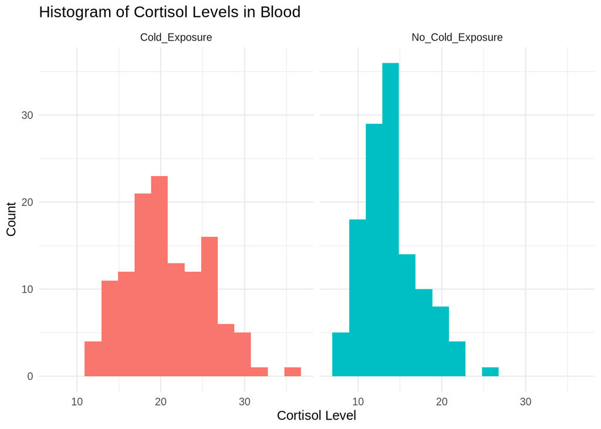

```r
Histogram1 <- ggplot(TidyColdShowerData, aes(x = Cortisol_Level, fill = Condition)) + geom_histogram(bins = 15) + facet_wrap(~Condition) + theme_minimal() + labs(title = "Histogram of Cortisol Levels in Blood", x = "Cortisol Level", y = "Count") + theme(legend.position = "none")
Histogram1
```

```r
Model <- lm(Cortisol_Level ~ Condition, data = TidyColdShowerData)
TidyColdShowerData$residuals <- residuals(Model)
Model
```

```
##
## Call:
## lm(formula = Cortisol_Level ~ Condition, data = TidyColdShowerData)
##
## Coefficients:
##               (Intercept)  ConditionNo_Cold_Exposure
##                    20.730                     -6.786
```

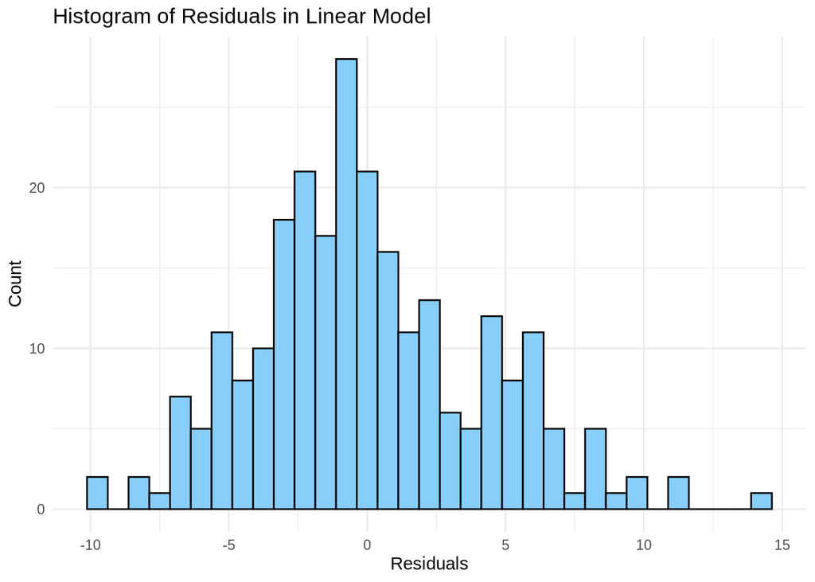

```r
Histogram2 <- ggplot(TidyColdShowerData, aes(x = residuals)) + geom_histogram(color = "black", fill = "lightskyblue", binwidth = 0.75) + theme_minimal() + labs(title = "Histogram of Residuals in Linear Model", x = "Residuals", y = "Count") + theme(legend.position = "none")
Histogram2
```

```r
kstest_result<- ks.test(TidyColdShowerData$residuals, "pnorm", mean = mean(TidyColdShowerData$residuals), sd = sd(TidyColdShowerData$residuals))
kstest_result
```

```
##
##  Asymptotic one-sample Kolmogorov-Smirnov test
##
## data:  TidyColdShowerData$residuals
## D = 0.083636, p-value = 0.06054
## alternative hypothesis: two-sided
```

```r
Model2<- lm(TidyColdShowerData$Cortisol_Level~TidyColdShowerData$Condition)
cooks.distance(Model2)
```

[output not shown]

[output cut: 29 more lines]

[output not shown]

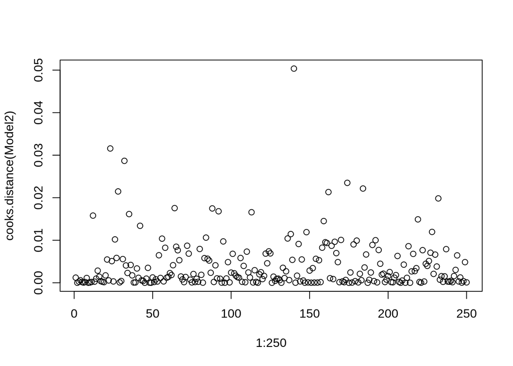

```r
plot(x=1:250, y=cooks.distance(Model2))
```

```r
which.max(cooks.distance(Model2))
```

```
## 140
## 140
```

```r
ResidualData <- TidyColdShowerData[-140,]
```

### *Interpretation of EDA:*

The assumptions for the 2 Sample T-Test were met in the necessary code in the Exploratory Data Analysis (EDA) by first reading the original CSV file that contained the data table values of cortisol levels in the blood between two responses (no cold water exposure and cold water exposure). This data table was converted to be tidy so that the observations could be interpreted properly. To visually observe normality, both original groups (cold water exposure and no cold water exposure) were represented with a histogram that clearly demonstrated an outlier in addition to the Kolmogorov-Smirnov test yielding a p-value greater than alpha value of 0.05. A histogram with residual data from the levels of cortisol was used as well to show an outlier in the residuals of the linear model. To statistically observe normality, a Kolmogorov-Smirnov test using the residual data from the linear model resulted in a p-value that was greater than the alpha value of 0.05. This shows that the null hypothesis should not be rejected. This p-value indicates that there is not enough evidence to prove that the data for cortisol levels in the blood were not normalized. This result comes from the significant outlier that is present in the histogram and cooks.distance plot seen to be greater than the rest of the points. Furthermore, a new data set was created where the outlier was completely removed using the which.max function (removing participant 140), which determines the data point with the greatest influence on regression coefficients based on the cooks.distance values.

# Primary Statistical Analysis

```r
#USE THIS BLOCK TO INPUT NECESSARY CODE.
t_test_result <- t.test(ResidualData$Cortisol_Level~ResidualData$Condition)
t_test_result
```

```
##
##  Welch Two Sample t-test
##
## data:  ResidualData$Cortisol_Level by ResidualData$Condition
## t = 12.978, df = 226.06, p-value < 2.2e-16
## alternative hypothesis: true difference in means between group Cold_Exposure and group No_Cold_Exposure is not equal to 0
## 95 percent confidence interval:
##  5.655517 7.680423
## sample estimates:
##    mean in group Cold_Exposure mean in group No_Cold_Exposure
##                       20.61219                       13.94423
```

# Data Visualization

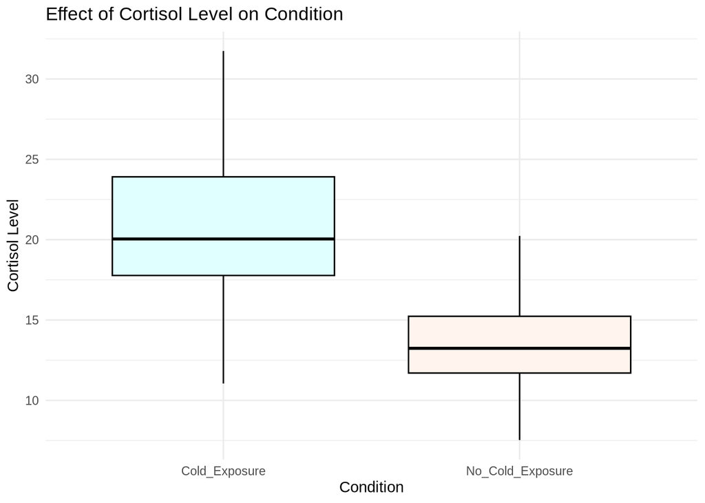

```r
#USE THIS BLOCK TO INPUT NECESSARY CODE.
plot1 <- ggplot(ResidualData, aes(x = Condition, y = Cortisol_Level, fill = Condition)) + geom_boxplot(color = "black", outlier.shape = NA) + scale_fill_manual(values = c("No_Cold_Exposure" ="seashell", "Cold_Exposure" = "lightcyan")) + theme_minimal() + labs(x = "Condition", y = "Cortisol Level", title = "Effect of Cortisol Level on Condition") + theme(legend.position = "none")
plot1
```

# Conclusions

Upon meeting the assumptions necessary for a 2 Sample T-Test, along with performing a statistical test to determine whether the data given deviates from normality, it is certain that there is a significant difference in the level of cortisol in the blood between participants who were exposed to cold water after the initial hot shower and were not exposed to cold water at all. Following the t-test (which was the primary statistical test used to test for normality) that was conducted, a p-value that was significantly less than the alpha value of 0.05 strongly indicates that the null hypothesis should be rejected, hence revealing a statistically significant difference in the data. The mean difference being a positive value explains that the mean in one group was higher than the other, which in this case indicates that cortisol levels are significantly higher in one group compared to the other. The two boxplot model shows that cold water exposure after an initial hot shower, produces more cortisol levels in the blood in comparison to no cold water exposure. As the mean difference falls within a ninety-five percent confidence interval of 5.655517 and 7.680423, the interval also does not include zero, meaning that the observed difference is not likely due to random chance. There is real evidence of a difference between the two groups in the population. There is enough data to conclude that showering with cold water exposure for a minute long after an initial hot shower will yield higher cortisol levels in the blood. One co-founding variable that was not considered in this follow-up study was various exposure duration to cold water. Exposing participants in cold water less than and greater than a minute after their initial hot shower can change the benefits of the cold water study. These different exposure levels can lead to a greater increase in cortisol levels, or a drop in cortisol levels depending on the set time intervals. If there were no restrictions placed upon my design, what I would do differently is to instruct participants to submerge themselves in an ice bath with temperatures ranging from 10-15°C to see if that drastically alters the level of cortisol in the blood.

# Citations

Microsoft Copilot: Your AI companion. (2025). Microsoft Copilot: Your AI Companion. https://copilot.microsoft.com/chats/zTwvSb9dpWMt5giyM6g6E

Cherney, K. (2020, June 22). Cold shower for anxiety: Research, efficacy, and more. Healthline. https://www.healthline.com/health/anxiety/cold-shower-for-anxiety

Buijze, G. A., Sierevelt, I. N., van der Heijden, B. C. J. M., Dijkgraaf, M. G., & Frings-Dresen, M. H. W. (2018). Correction: The Effect of Cold Showering on Health and Work: A Randomized Controlled Trial. PLOS ONE, 13(8), e0201978. https://doi.org/10.1371/journal.pone.0201978